# Programing fundamentals

**KEY VERSION**

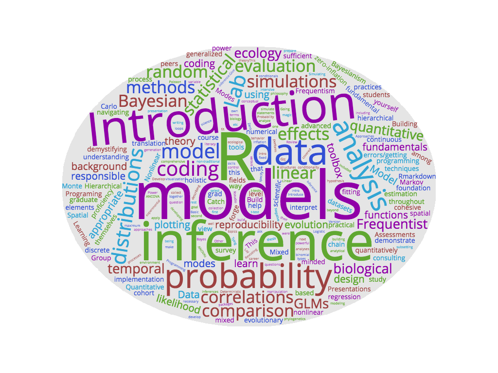

*Below are a set of excercises to get you practicing with R*

## A. Practice the analysis pipeline using control statements!

#### Write a script that completes the following tasks:

*Be sure to write your name and the date at the top of the script in a comment*

*This is a complicated one, but here is some psuedocode to help you out*

```
# read in the data using read.csv()

# check the structure using str()

# set the graphing window parameters using par() and the mfrow argument

# start the for loop (run it from 1 to 9, which is ncol(possum)-1)

# using an if statement, test if the ith column is numeric

#if the column is numeric, create a plot with the ith column as the x and the last column as the y

#end the if statement

#end the for loop
```

```r
#ANSWER

#Name
#Date
rm(list=ls())
```

```r
possum<-read.csv("possum_trimmed.csv")
str(possum)
```

```
## 'data.frame':    104 obs. of  10 variables:
##  $ sex     : chr  "m" "f" "f" "f" ...
##  $ age     : int  8 6 6 6 2 1 2 6 9 6 ...
##  $ hdlngth : num  94.1 92.5 94 93.2 91.5 93.1 95.3 94.8 93.4 91.8 ...
##  $ skullw  : num  60.4 57.6 60 57.1 56.3 54.8 58.2 57.6 56.3 58 ...
##  $ totlngth: num  89 91.5 95.5 92 85.5 90.5 89.5 91 91.5 89.5 ...
##  $ taill   : num  36 36.5 39 38 36 35.5 36 37 37 37.5 ...
##  $ footlgth: num  74.5 72.5 75.4 76.1 71 73.2 71.5 72.7 72.4 70.9 ...
##  $ earconch: num  54.5 51.2 51.9 52.2 53.2 53.6 52 53.9 52.9 53.4 ...
##  $ eye     : num  15.2 16 15.5 15.2 15.1 ...
##  $ belly   : num  36 33 34 34 33 32 34.5 34 33 32 ...
```

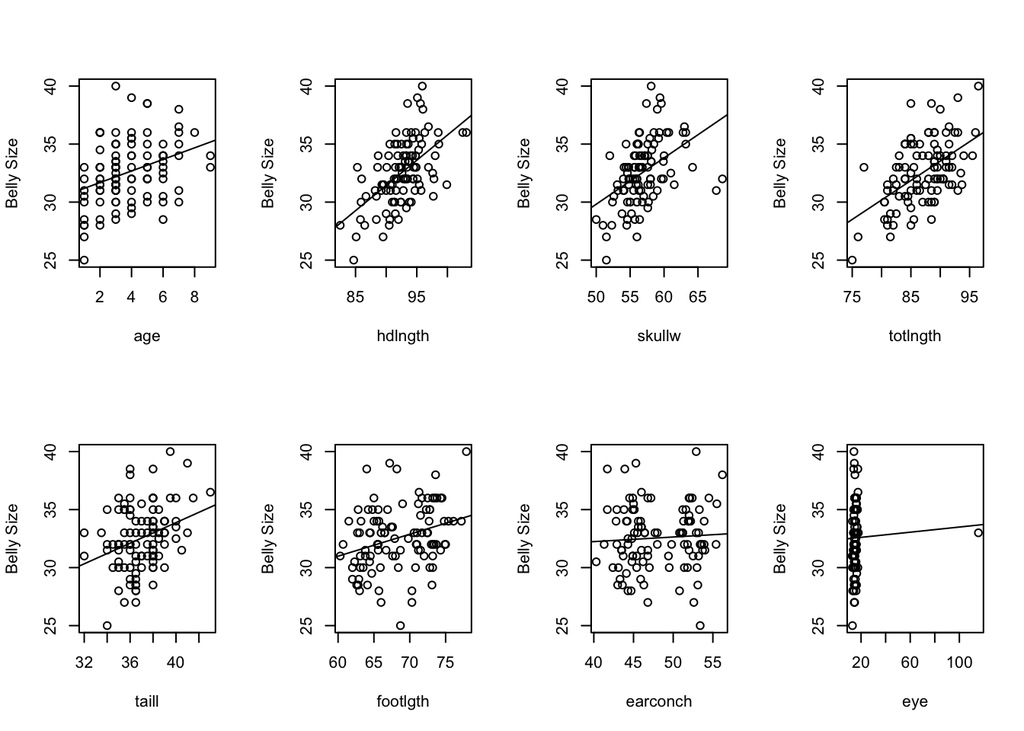

```r
par(mfrow=c(2,4))
for (i in 1:9){
if(is.numeric(possum[,i])){
  plot(y=possum[,10], x=possum[,i], xlab=colnames(possum)[i],ylab="Belly Size")
  abline(lm(possum[,10]~possum[,i]))
  }
}
```

## B. More practice with `for` loops

**Using the built in data set `USPersonalExpenditure` write `for` loop that takes the mean amount spent on each category from 1940-1960. Use the result to make a barplot of the mean expenditures for each category.**

*hints: First create an empty vector named `uspe.means` **(use= uspe.means <- vector())**. In the for loop, populate the vector with the means of each category, AND name each vector element using ‘names(uspe.means)’. Then use `barplot()` to make the graphic.*

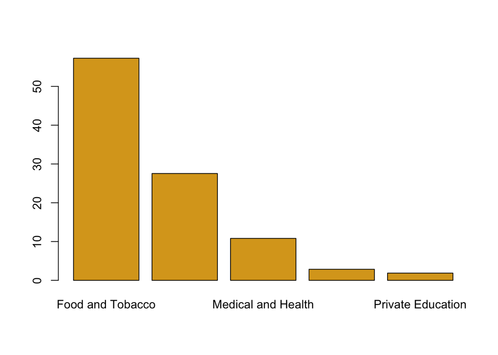

```r
#ANSWER:
uspe.means <- vector()
for(i in 1:5){
  uspe.means[i] <- mean(USPersonalExpenditure[i,])
  names(uspe.means)[i]<-row.names(USPersonalExpenditure)[i]
}
barplot(uspe.means,col="goldenrod")
```

## C. Writing your own functions

**Write a function which:**

Takes a file name and two numbers (the defaults for the two numbers should be 1 and 2)

Reads in a table of data (assume that the file is comma delimited)

Plots the columns represented by the two numbers against each other

*Hints: Use the read.csv() function Use print() to check the values of intermediate results (to see if your function is working) Use the test file ”primates.csv" to check your program.

```
##               Bodywt Brainwt
## Potar monkey    10.0     115
## Gorilla        207.0     406
## Human           62.0    1320
## Rhesus monkey    6.8     179
## Chimp           52.2     440
```

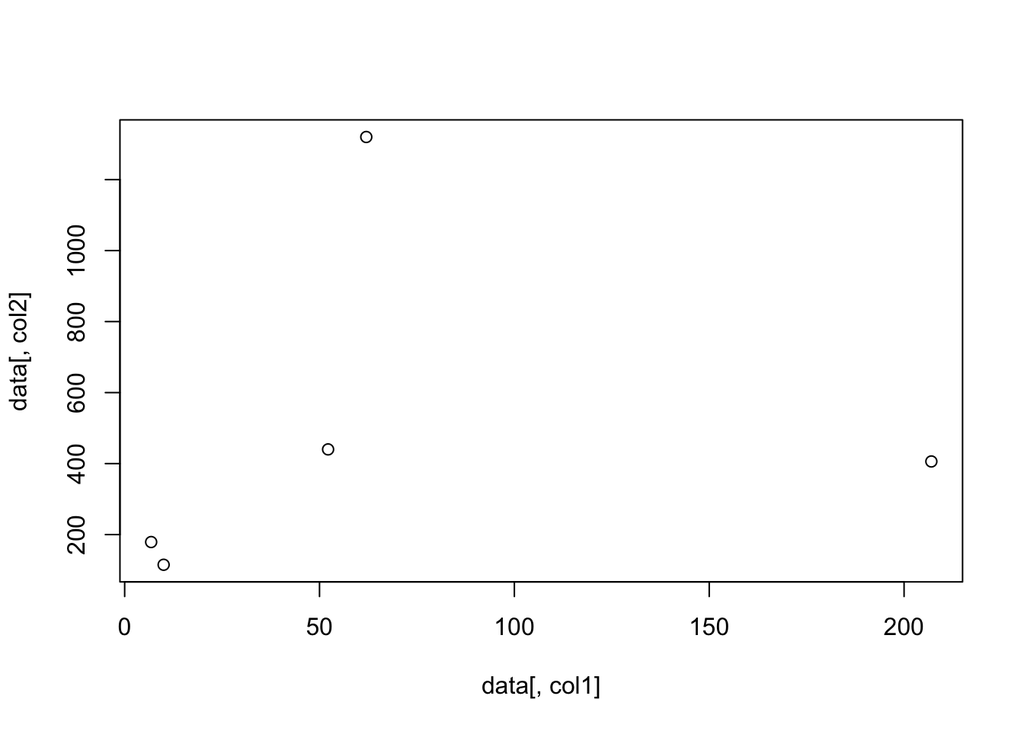

```r
plot.columns <- function(filename, col1=1, col2=2) {
   data <- read.csv(filename, header=T, row.names=1)
   print(data)
   plot(data[,col1], data[,col2])
}

plot.columns(filename="primates.csv")
```